# LA.4: Working with Data (10 points)

# Resources

- [Video 05: Data Management](https://youtu.be/b9Bh3K5bi0I)
- [COMM 3710: Getting Started with R](https://sarakyeo.github.io/COMM-3710-bookdown/docs/index.html)

# Data

For this assignment, you will be working with the [Health Evaluation and Linkage to Primary Care (HELP) data set](https://utah.instructure.com/files/108105219/download?download_frd=1). Submit your answers as a PDF document on Canvas.

The HELP study was a clinical trial for adult inpatients recruited from a detoxification unit. Patients with no primary care physician were randomized to receive a multidisciplinary assessment and a brief motivational intervention or usual care, with the goal of linking them to primary medical care.

The data set contains 453 observations on the following variables:

- `age`: Subject age at baseline (in years)
- `anysub`: Use of any substance post-detox (a factor with levels no yes)
- `cesd`: Center for Epidemiologic Studies Depression measure at baseline (high scores indicate more depressive symptoms)
- `d1`: lifetime number of hospitalizations for medical problems (measured at baseline)
- `daysanysub`: time (in days) to first use of any substance post-detox
- `dayslink`: time (in days) to linkage to primary care
- `drugrisk`: Risk Assessment Battery drug risk scale at baseline
- `e2b`: number of times in past 6 months entered a detox program (measured at baseline)
- `female`: 0 for male, 1 for female
- `sex`: a factor with levels male female
- `g1b`: experienced serious thoughts of suicide in last 30 days (measured at baseline; a factor with levels no yes)
- `homeless`: housing status: a factor with levels housed homeless
- `i1`: average number of drinks (standard units) consumed per day, in the past 30 days (measured at baseline)
- `i2`: maximum number of drinks (standard units) consumed per day, in the past 30 days (measured at baseline)
- `id`: subject identifier
- `indtot`: Inventory of Drug Use Consequences (InDUC) total score (measured at baseline)
- `linkstatus`: post-detox linkage to primary care (0 = no, 1 = yes)
- `link`: post-detox linkage to primary care: no yes
- `mcs`: SF-36 Mental Component Score (measured at baseline, lower scores indicate worse status)
- `pcs`: SF-36 Physical Component Score (measured at baseline, lower scores indicate worse status)
- `pss_fr`: perceived social support by friends (measured at baseline, higher scores indicate more support)
- `racegrp`: race/ethnicity: levels black hispanic other white
- `satreat`: any BSAS substance abuse treatment at baseline (no yes)
- `sexrisk`: Risk Assessment Battery sex risk score (measured at baseline)
- `substance`: primary substance of abuse (alcohol cocaine heroin)
- `treat`: randomized to HELP clinic (no yes)

# Instructions

## Step 1

### Question

Load in the [HELP data set](https://utah.instructure.com/files/108105219/download?download_frd=1) that we used in [LA.3](https://sarakyeo.github.io/COMM-3710/LA/LA.3.html).

## Step 2

### Question

Patients with a mental component score (`mcs`) less than 20 are thought to be at extreme risk of returning to the detoxification unit within the next 12 months.

Make a new variable called `ExtremeMCS` and code it as `1` if a patient is at risk based on his/her mcs score and `0` otherwise.

### Hint

In addition to the method shown in the video, you can create this new variable using the `ifelse` command.

Figure out what the arguments (the text and numbers within the parentheses) in the `ifelse` function mean by typing `?ifelse` into the Console in RStudio and reading the documentation.

The code below creates a new variable called `alcohol` based on the existing variable, `substance`, in the HELP data set, which has been read into a data frame called `hdata`. It recodes the `substance` variable into a new variable that assigns `1` to any patient whose primary substance of abuse is alcohol and `0` to patients whose primary substance of abuse is cocaine or heroine.

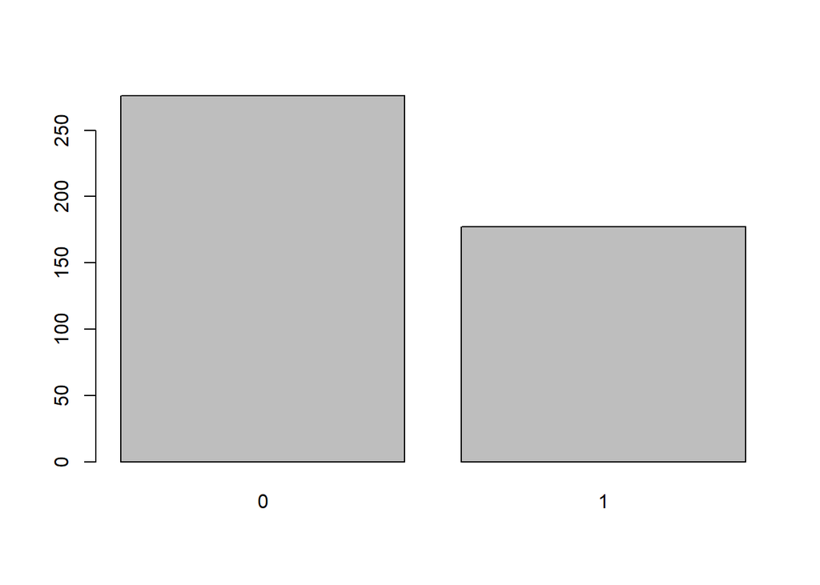

```
## hdata$alcohol
##       Frequency Percent
## 0           276   60.93
## 1           177   39.07
## Total       453  100.00
```

```r
> hdata$alcohol <- ifelse(hdata$substance == "alcohol", 1, 0)
> freq(hdata$alcohol)
```

## Step 4

Make a new variable `HomelessStatus` based on the variable `homeless`. Have `1` indicate that a patient is homeless and `0` indicate that they are housed.

## Step 5

### Question

Suppose we want to assess the overall risk a patient has to return to the detoxification unit and `ExtremeMCS`, `SuicidalThought`, and `HomelessStatus` are considered risk factors. Construct a new variable called `RiskTotal` which computes the number of risk factors a particular patient has. That is, make it a sum of these 3 variables.

### Hint

You want to create a new variable called `RiskTotal`, which is the sum of `ExtremeMCS`, `SuicidalThought`, and `HomelessStatus`. First, try the most straightforward way, which is to use this general formula:

```
Dataframe$NewVariable <- Dataframe$Var1 + Dataframe$Var2 + Dataframe$Var3
```

Like most things in R, there are many other ways to do this. One way is to transform the data using the command, `transform`. Get help with `transform` by typing `?transform` into the Console and reading the documentation.

## Step 6

### Question

Make frequency tables of `ExtremeMCS`, `SuicidalThought`, and `RiskTotal`. Answer the following questions.

1. How many patients are thought to be at risk based on their `mcs` score?
2. What percentage of patients have experienced suicidal thoughts?
3. What percentage of patients in the study have fewer than 3 risk factors?

### Hint

Refer to LA.3 to review creating frequency tables.

## Submission

Submit a **.R file** containing the following on Canvas:

- R code/commands used to complete this assignment. Your R script should include annotations that explain your thought process as you work through the assignment.
- Clearly labeled answers to questions as comments/annotations in the R script.